# Risk Factor Analysis

## Outcome Variable

**Outcome Variable:** ever_stunted

## Predictor Variables

**Intervention Variable:** single

**Adjustment Set:**

- arm
- W_mage
- meducyrs
- feducyrs
- W_mhtcm
- W_mwtkg
- W_mbmi
- delta_W_mage
- delta_meducyrs
- delta_feducyrs
- delta_W_mhtcm
- delta_W_mwtkg
- delta_W_mbmi

## Stratifying Variables

The analysis was stratified on these variable(s):

- agecat
- studyid
- country

## Data Summary

| agecat | studyid | country | single | ever_stunted | n_cell | n |
| --- | --- | --- | --- | --- | --- | --- |
| 0-24 months | COHORTS | GUATEMALA | 0 | 0 | 254 | 1207 |
| 0-24 months | COHORTS | GUATEMALA | 0 | 1 | 855 | 1207 |
| 0-24 months | COHORTS | GUATEMALA | 1 | 0 | 12 | 1207 |
| 0-24 months | COHORTS | GUATEMALA | 1 | 1 | 86 | 1207 |
| 0-24 months | COHORTS | INDIA | 0 | 0 | 3293 | 5384 |
| 0-24 months | COHORTS | INDIA | 0 | 1 | 2082 | 5384 |
| 0-24 months | COHORTS | INDIA | 1 | 0 | 4 | 5384 |
| 0-24 months | COHORTS | INDIA | 1 | 1 | 5 | 5384 |
| 0-24 months | COHORTS | PHILIPPINES | 0 | 0 | 924 | 3018 |
| 0-24 months | COHORTS | PHILIPPINES | 0 | 1 | 2019 | 3018 |
| 0-24 months | COHORTS | PHILIPPINES | 1 | 0 | 21 | 3018 |
| 0-24 months | COHORTS | PHILIPPINES | 1 | 1 | 54 | 3018 |
| 0-24 months | Guatemala BSC | GUATEMALA | 0 | 0 | 118 | 282 |
| 0-24 months | Guatemala BSC | GUATEMALA | 0 | 1 | 134 | 282 |
| 0-24 months | Guatemala BSC | GUATEMALA | 1 | 0 | 8 | 282 |
| 0-24 months | Guatemala BSC | GUATEMALA | 1 | 1 | 22 | 282 |
| 0-24 months | JiVitA-4 | BANGLADESH | 0 | 0 | 2263 | 5423 |
| 0-24 months | JiVitA-4 | BANGLADESH | 0 | 1 | 3152 | 5423 |
| 0-24 months | JiVitA-4 | BANGLADESH | 1 | 0 | 4 | 5423 |
| 0-24 months | JiVitA-4 | BANGLADESH | 1 | 1 | 4 | 5423 |
| 0-24 months | MAL-ED | BANGLADESH | 0 | 0 | 103 | 265 |
| 0-24 months | MAL-ED | BANGLADESH | 0 | 1 | 162 | 265 |
| 0-24 months | MAL-ED | BANGLADESH | 1 | 0 | 0 | 265 |
| 0-24 months | MAL-ED | BANGLADESH | 1 | 1 | 0 | 265 |
| 0-24 months | MAL-ED | BRAZIL | 0 | 0 | 148 | 233 |
| 0-24 months | MAL-ED | BRAZIL | 0 | 1 | 49 | 233 |
| 0-24 months | MAL-ED | BRAZIL | 1 | 0 | 22 | 233 |
| 0-24 months | MAL-ED | BRAZIL | 1 | 1 | 14 | 233 |
| 0-24 months | MAL-ED | INDIA | 0 | 0 | 99 | 249 |
| 0-24 months | MAL-ED | INDIA | 0 | 1 | 150 | 249 |

[output cut: 150 more lines]

The following strata were considered:

- agecat: 0-24 months, studyid: COHORTS, country: GUATEMALA
- agecat: 0-24 months, studyid: COHORTS, country: INDIA
- agecat: 0-24 months, studyid: COHORTS, country: PHILIPPINES
- agecat: 0-24 months, studyid: Guatemala BSC, country: GUATEMALA
- agecat: 0-24 months, studyid: JiVitA-4, country: BANGLADESH
- agecat: 0-24 months, studyid: MAL-ED, country: BANGLADESH
- agecat: 0-24 months, studyid: MAL-ED, country: BRAZIL
- agecat: 0-24 months, studyid: MAL-ED, country: INDIA
- agecat: 0-24 months, studyid: MAL-ED, country: NEPAL
- agecat: 0-24 months, studyid: MAL-ED, country: PERU
- agecat: 0-24 months, studyid: MAL-ED, country: SOUTH AFRICA
- agecat: 0-24 months, studyid: MAL-ED, country: TANZANIA, UNITED REPUBLIC OF
- agecat: 0-24 months, studyid: PROBIT, country: BELARUS
- agecat: 0-24 months, studyid: TanzaniaChild2, country: TANZANIA, UNITED REPUBLIC OF
- agecat: 0-24 months, studyid: ZVITAMBO, country: ZIMBABWE
- agecat: 0-6 months, studyid: COHORTS, country: GUATEMALA
- agecat: 0-6 months, studyid: COHORTS, country: INDIA
- agecat: 0-6 months, studyid: COHORTS, country: PHILIPPINES
- agecat: 0-6 months, studyid: Guatemala BSC, country: GUATEMALA
- agecat: 0-6 months, studyid: JiVitA-4, country: BANGLADESH
- agecat: 0-6 months, studyid: MAL-ED, country: BANGLADESH
- agecat: 0-6 months, studyid: MAL-ED, country: BRAZIL
- agecat: 0-6 months, studyid: MAL-ED, country: INDIA
- agecat: 0-6 months, studyid: MAL-ED, country: NEPAL
- agecat: 0-6 months, studyid: MAL-ED, country: PERU
- agecat: 0-6 months, studyid: MAL-ED, country: SOUTH AFRICA
- agecat: 0-6 months, studyid: MAL-ED, country: TANZANIA, UNITED REPUBLIC OF
- agecat: 0-6 months, studyid: PROBIT, country: BELARUS
- agecat: 0-6 months, studyid: TanzaniaChild2, country: TANZANIA, UNITED REPUBLIC OF
- agecat: 0-6 months, studyid: ZVITAMBO, country: ZIMBABWE
- agecat: 6-24 months, studyid: COHORTS, country: GUATEMALA
- agecat: 6-24 months, studyid: COHORTS, country: INDIA
- agecat: 6-24 months, studyid: COHORTS, country: PHILIPPINES
- agecat: 6-24 months, studyid: Guatemala BSC, country: GUATEMALA
- agecat: 6-24 months, studyid: JiVitA-4, country: BANGLADESH
- agecat: 6-24 months, studyid: MAL-ED, country: BANGLADESH
- agecat: 6-24 months, studyid: MAL-ED, country: BRAZIL
- agecat: 6-24 months, studyid: MAL-ED, country: INDIA
- agecat: 6-24 months, studyid: MAL-ED, country: NEPAL
- agecat: 6-24 months, studyid: MAL-ED, country: PERU
- agecat: 6-24 months, studyid: MAL-ED, country: SOUTH AFRICA
- agecat: 6-24 months, studyid: MAL-ED, country: TANZANIA, UNITED REPUBLIC OF
- agecat: 6-24 months, studyid: PROBIT, country: BELARUS
- agecat: 6-24 months, studyid: TanzaniaChild2, country: TANZANIA, UNITED REPUBLIC OF
- agecat: 6-24 months, studyid: ZVITAMBO, country: ZIMBABWE

### Dropped Strata

Some strata were dropped due to rare outcomes:

- agecat: 0-24 months, studyid: COHORTS, country: INDIA
- agecat: 0-24 months, studyid: JiVitA-4, country: BANGLADESH
- agecat: 0-24 months, studyid: MAL-ED, country: BANGLADESH
- agecat: 0-24 months, studyid: MAL-ED, country: INDIA
- agecat: 0-24 months, studyid: MAL-ED, country: NEPAL
- agecat: 0-24 months, studyid: MAL-ED, country: TANZANIA, UNITED REPUBLIC OF
- agecat: 0-6 months, studyid: COHORTS, country: INDIA
- agecat: 0-6 months, studyid: JiVitA-4, country: BANGLADESH
- agecat: 0-6 months, studyid: MAL-ED, country: BANGLADESH
- agecat: 0-6 months, studyid: MAL-ED, country: INDIA
- agecat: 0-6 months, studyid: MAL-ED, country: NEPAL
- agecat: 0-6 months, studyid: MAL-ED, country: TANZANIA, UNITED REPUBLIC OF
- agecat: 6-24 months, studyid: COHORTS, country: INDIA
- agecat: 6-24 months, studyid: JiVitA-4, country: BANGLADESH
- agecat: 6-24 months, studyid: MAL-ED, country: BANGLADESH
- agecat: 6-24 months, studyid: MAL-ED, country: BRAZIL
- agecat: 6-24 months, studyid: MAL-ED, country: INDIA
- agecat: 6-24 months, studyid: MAL-ED, country: NEPAL
- agecat: 6-24 months, studyid: MAL-ED, country: TANZANIA, UNITED REPUBLIC OF

## Methods Detail

We're interested in the causal parameters $E[Y_a]$ for all values of $a \in \mathcal{A}$. These parameters represent the mean outcome if, possibly contrary to fact, we intervened to set all units to have $A=a$. Under the randomization and positivity assumptions, these are identified by the statistical parameters $\psi_a=E_W[E_{Y|A,W}(Y|A=a,W)]$. In addition, we're interested in the mean of $Y$, $E[Y]$ under no intervention (the observed mean). We will estimate these parameters by using SuperLearner to fit the relevant likelihood factors -- $E_{Y|A,W}(Y|A=a,W)$ and $p(A=a|W)$, and then updating our likelihood fit using a joint TMLE.

For unadjusted analyses ($W=\{\}$), initial likelihoods were estimated using Lrnr_glm to estimate the simple $E(Y|A)$ and Lrnr_mean to estimate $p(A)$. For adjusted analyses, a small library containing Lrnr_glmnet, Lrnr_xgboost, and Lrnr_mean was used.

Having estimated these parameters, we will then use the delta method to estimate relative risks and attributable risks relative to a prespecified baseline level of $A$.

# Results Detail

## Results Plots

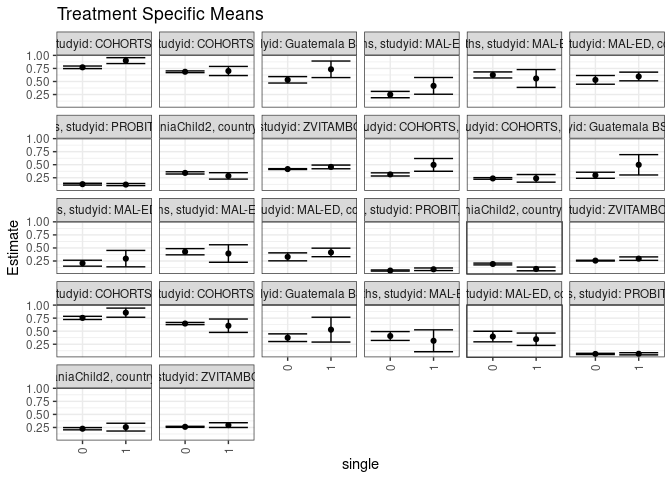

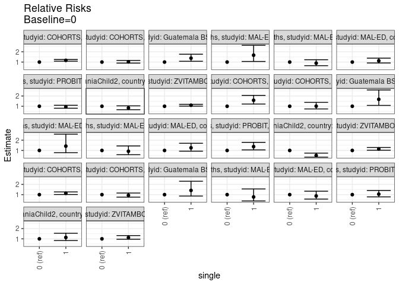

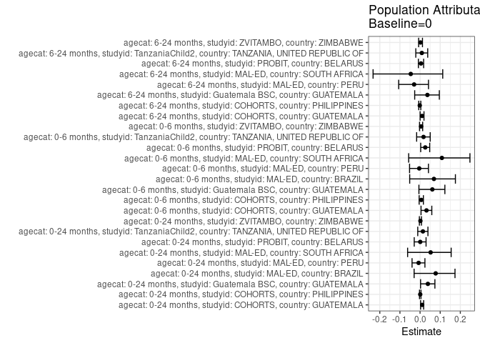

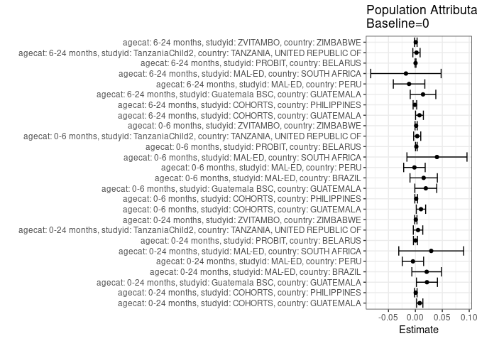

## Results Table

### Parameter: TSM

| agecat | studyid | country | intervention_level | baseline_level | estimate | ci_lower | ci_upper |
| --- | --- | --- | --- | --- | --- | --- | --- |
| 0-24 months | COHORTS | GUATEMALA | 0 | NA | 0.7715758 | 0.7468557 | 0.7962960 |
| 0-24 months | COHORTS | GUATEMALA | 1 | NA | 0.8995276 | 0.8429673 | 0.9560880 |
| 0-24 months | COHORTS | PHILIPPINES | 0 | NA | 0.6862867 | 0.6694357 | 0.7031376 |
| 0-24 months | COHORTS | PHILIPPINES | 1 | NA | 0.7008789 | 0.6138012 | 0.7879567 |
| 0-24 months | Guatemala BSC | GUATEMALA | 0 | NA | 0.5317460 | 0.4700280 | 0.5934641 |
| 0-24 months | Guatemala BSC | GUATEMALA | 1 | NA | 0.7333333 | 0.5748097 | 0.8918569 |
| 0-24 months | MAL-ED | BRAZIL | 0 | NA | 0.2494131 | 0.1888458 | 0.3099803 |
| 0-24 months | MAL-ED | BRAZIL | 1 | NA | 0.4163005 | 0.2561870 | 0.5764139 |
| 0-24 months | MAL-ED | PERU | 0 | NA | 0.6250145 | 0.5669241 | 0.6831049 |
| 0-24 months | MAL-ED | PERU | 1 | NA | 0.5574211 | 0.3868517 | 0.7279905 |
| 0-24 months | MAL-ED | SOUTH AFRICA | 0 | NA | 0.5310905 | 0.4475377 | 0.6146434 |
| 0-24 months | MAL-ED | SOUTH AFRICA | 1 | NA | 0.5960478 | 0.5128387 | 0.6792570 |
| 0-24 months | PROBIT | BELARUS | 0 | NA | 0.1273108 | 0.1102506 | 0.1443710 |
| 0-24 months | PROBIT | BELARUS | 1 | NA | 0.1196974 | 0.0996152 | 0.1397796 |
| 0-24 months | TanzaniaChild2 | TANZANIA, UNITED REPUBLIC OF | 0 | NA | 0.3432879 | 0.3219608 | 0.3646150 |
| 0-24 months | TanzaniaChild2 | TANZANIA, UNITED REPUBLIC OF | 1 | NA | 0.2854506 | 0.2241043 | 0.3467969 |
| 0-24 months | ZVITAMBO | ZIMBABWE | 0 | NA | 0.4164852 | 0.4080447 | 0.4249257 |
| 0-24 months | ZVITAMBO | ZIMBABWE | 1 | NA | 0.4578023 | 0.4222912 | 0.4933134 |
| 0-6 months | COHORTS | GUATEMALA | 0 | NA | 0.3140668 | 0.2838163 | 0.3443172 |
| 0-6 months | COHORTS | GUATEMALA | 1 | NA | 0.4968898 | 0.3743566 | 0.6194230 |
| 0-6 months | COHORTS | PHILIPPINES | 0 | NA | 0.2371331 | 0.2216719 | 0.2525943 |
| 0-6 months | COHORTS | PHILIPPINES | 1 | NA | 0.2389665 | 0.1658766 | 0.3120564 |
| 0-6 months | Guatemala BSC | GUATEMALA | 0 | NA | 0.2976561 | 0.2393692 | 0.3559430 |
| 0-6 months | Guatemala BSC | GUATEMALA | 1 | NA | 0.4983805 | 0.3035411 | 0.6932200 |
| 0-6 months | MAL-ED | BRAZIL | 0 | NA | 0.2077953 | 0.1509571 | 0.2646334 |
| 0-6 months | MAL-ED | BRAZIL | 1 | NA | 0.2952570 | 0.1382360 | 0.4522780 |
| 0-6 months | MAL-ED | PERU | 0 | NA | 0.4275234 | 0.3682540 | 0.4867929 |
| 0-6 months | MAL-ED | PERU | 1 | NA | 0.3934025 | 0.2256178 | 0.5611871 |
| 0-6 months | MAL-ED | SOUTH AFRICA | 0 | NA | 0.3293583 | 0.2529542 | 0.4057624 |
| 0-6 months | MAL-ED | SOUTH AFRICA | 1 | NA | 0.4139170 | 0.3320901 | 0.4957439 |
| 0-6 months | PROBIT | BELARUS | 0 | NA | 0.0668429 | 0.0560227 | 0.0776631 |
| 0-6 months | PROBIT | BELARUS | 1 | NA | 0.0917701 | 0.0667416 | 0.1167986 |
| 0-6 months | TanzaniaChild2 | TANZANIA, UNITED REPUBLIC OF | 0 | NA | 0.1924104 | 0.1751595 | 0.2096612 |
| 0-6 months | TanzaniaChild2 | TANZANIA, UNITED REPUBLIC OF | 1 | NA | 0.0978275 | 0.0622890 | 0.1333660 |
| 0-6 months | ZVITAMBO | ZIMBABWE | 0 | NA | 0.2574556 | 0.2499494 | 0.2649618 |
| 0-6 months | ZVITAMBO | ZIMBABWE | 1 | NA | 0.2950606 | 0.2618214 | 0.3282998 |
| 6-24 months | COHORTS | GUATEMALA | 0 | NA | 0.7546174 | 0.7239651 | 0.7852698 |
| 6-24 months | COHORTS | GUATEMALA | 1 | NA | 0.8548387 | 0.7671013 | 0.9425761 |
| 6-24 months | COHORTS | PHILIPPINES | 0 | NA | 0.6461319 | 0.6253573 | 0.6669065 |
| 6-24 months | COHORTS | PHILIPPINES | 1 | NA | 0.6044613 | 0.4766530 | 0.7322697 |
| 6-24 months | Guatemala BSC | GUATEMALA | 0 | NA | 0.3750000 | 0.3015949 | 0.4484051 |
| 6-24 months | Guatemala BSC | GUATEMALA | 1 | NA | 0.5294118 | 0.2914989 | 0.7673246 |
| 6-24 months | MAL-ED | PERU | 0 | NA | 0.4076923 | 0.3229347 | 0.4924499 |
| 6-24 months | MAL-ED | PERU | 1 | NA | 0.3157895 | 0.1060755 | 0.5255034 |
| 6-24 months | MAL-ED | SOUTH AFRICA | 0 | NA | 0.3972890 | 0.2962889 | 0.4982892 |
| 6-24 months | MAL-ED | SOUTH AFRICA | 1 | NA | 0.3457488 | 0.2274677 | 0.4640300 |
| 6-24 months | PROBIT | BELARUS | 0 | NA | 0.0639614 | 0.0522447 | 0.0756780 |
| 6-24 months | PROBIT | BELARUS | 1 | NA | 0.0671477 | 0.0463566 | 0.0879387 |
| 6-24 months | TanzaniaChild2 | TANZANIA, UNITED REPUBLIC OF | 0 | NA | 0.2258059 | 0.2041945 | 0.2474173 |
| 6-24 months | TanzaniaChild2 | TANZANIA, UNITED REPUBLIC OF | 1 | NA | 0.2563716 | 0.1813059 | 0.3314372 |
| 6-24 months | ZVITAMBO | ZIMBABWE | 0 | NA | 0.2623395 | 0.2526484 | 0.2720306 |
| 6-24 months | ZVITAMBO | ZIMBABWE | 1 | NA | 0.2952214 | 0.2498794 | 0.3405635 |

### Parameter: E(Y)

| agecat | studyid | country | intervention_level | baseline_level | estimate | ci_lower | ci_upper |
| --- | --- | --- | --- | --- | --- | --- | --- |
| 0-24 months | COHORTS | GUATEMALA | NA | NA | 0.7796189 | 0.7562250 | 0.8030128 |
| 0-24 months | COHORTS | PHILIPPINES | NA | NA | 0.6868787 | 0.6703303 | 0.7034272 |
| 0-24 months | Guatemala BSC | GUATEMALA | NA | NA | 0.5531915 | 0.4950624 | 0.6113206 |
| 0-24 months | MAL-ED | BRAZIL | NA | NA | 0.2703863 | 0.2132328 | 0.3275398 |
| 0-24 months | MAL-ED | PERU | NA | NA | 0.6204620 | 0.5657315 | 0.6751926 |
| 0-24 months | MAL-ED | SOUTH AFRICA | NA | NA | 0.5605096 | 0.5055248 | 0.6154943 |
| 0-24 months | PROBIT | BELARUS | NA | NA | 0.1274191 | 0.1115552 | 0.1432829 |
| 0-24 months | TanzaniaChild2 | TANZANIA, UNITED REPUBLIC OF | NA | NA | 0.3482105 | 0.3290467 | 0.3673744 |
| 0-24 months | ZVITAMBO | ZIMBABWE | NA | NA | 0.4172374 | 0.4090737 | 0.4254012 |
| 0-6 months | COHORTS | GUATEMALA | NA | NA | 0.3244353 | 0.2950189 | 0.3538517 |
| 0-6 months | COHORTS | PHILIPPINES | NA | NA | 0.2385686 | 0.2233602 | 0.2537770 |
| 0-6 months | Guatemala BSC | GUATEMALA | NA | NA | 0.3169811 | 0.2608532 | 0.3731091 |
| 0-6 months | MAL-ED | BRAZIL | NA | NA | 0.2231760 | 0.1695976 | 0.2767543 |
| 0-6 months | MAL-ED | PERU | NA | NA | 0.4257426 | 0.3699763 | 0.4815088 |
| 0-6 months | MAL-ED | SOUTH AFRICA | NA | NA | 0.3694268 | 0.3159570 | 0.4228965 |
| 0-6 months | PROBIT | BELARUS | NA | NA | 0.0686124 | 0.0577768 | 0.0794479 |
| 0-6 months | TanzaniaChild2 | TANZANIA, UNITED REPUBLIC OF | NA | NA | 0.1957895 | 0.1798275 | 0.2117515 |
| 0-6 months | ZVITAMBO | ZIMBABWE | NA | NA | 0.2588042 | 0.2515487 | 0.2660597 |
| 6-24 months | COHORTS | GUATEMALA | NA | NA | 0.7621951 | 0.7330377 | 0.7913526 |
| 6-24 months | COHORTS | PHILIPPINES | NA | NA | 0.6452074 | 0.6247246 | 0.6656902 |
| 6-24 months | Guatemala BSC | GUATEMALA | NA | NA | 0.3891892 | 0.3187405 | 0.4596379 |
| 6-24 months | MAL-ED | PERU | NA | NA | 0.3959732 | 0.3171819 | 0.4747644 |
| 6-24 months | MAL-ED | SOUTH AFRICA | NA | NA | 0.3797468 | 0.3038314 | 0.4556622 |
| 6-24 months | PROBIT | BELARUS | NA | NA | 0.0642659 | 0.0526827 | 0.0758490 |
| 6-24 months | TanzaniaChild2 | TANZANIA, UNITED REPUBLIC OF | NA | NA | 0.2278162 | 0.2071874 | 0.2484451 |
| 6-24 months | ZVITAMBO | ZIMBABWE | NA | NA | 0.2629713 | 0.2535901 | 0.2723525 |

### Parameter: RR

| agecat | studyid | country | intervention_level | baseline_level | estimate | ci_lower | ci_upper |
| --- | --- | --- | --- | --- | --- | --- | --- |
| 0-24 months | COHORTS | GUATEMALA | 0 | 0 | 1.0000000 | 1.0000000 | 1.0000000 |
| 0-24 months | COHORTS | GUATEMALA | 1 | 0 | 1.1658318 | 1.0865630 | 1.2508835 |
| 0-24 months | COHORTS | PHILIPPINES | 0 | 0 | 1.0000000 | 1.0000000 | 1.0000000 |
| 0-24 months | COHORTS | PHILIPPINES | 1 | 0 | 1.0212627 | 0.8999459 | 1.1589335 |
| 0-24 months | Guatemala BSC | GUATEMALA | 0 | 0 | 1.0000000 | 1.0000000 | 1.0000000 |
| 0-24 months | Guatemala BSC | GUATEMALA | 1 | 0 | 1.3791045 | 1.0790454 | 1.7626034 |
| 0-24 months | MAL-ED | BRAZIL | 0 | 0 | 1.0000000 | 1.0000000 | 1.0000000 |
| 0-24 months | MAL-ED | BRAZIL | 1 | 0 | 1.6691205 | 1.0580006 | 2.6332341 |
| 0-24 months | MAL-ED | PERU | 0 | 0 | 1.0000000 | 1.0000000 | 1.0000000 |
| 0-24 months | MAL-ED | PERU | 1 | 0 | 0.8918532 | 0.6480625 | 1.2273541 |
| 0-24 months | MAL-ED | SOUTH AFRICA | 0 | 0 | 1.0000000 | 1.0000000 | 1.0000000 |
| 0-24 months | MAL-ED | SOUTH AFRICA | 1 | 0 | 1.1223093 | 0.9114973 | 1.3818780 |
| 0-24 months | PROBIT | BELARUS | 0 | 0 | 1.0000000 | 1.0000000 | 1.0000000 |
| 0-24 months | PROBIT | BELARUS | 1 | 0 | 0.9401983 | 0.8057952 | 1.0970194 |
| 0-24 months | TanzaniaChild2 | TANZANIA, UNITED REPUBLIC OF | 0 | 0 | 1.0000000 | 1.0000000 | 1.0000000 |
| 0-24 months | TanzaniaChild2 | TANZANIA, UNITED REPUBLIC OF | 1 | 0 | 0.8315195 | 0.6653202 | 1.0392358 |
| 0-24 months | ZVITAMBO | ZIMBABWE | 0 | 0 | 1.0000000 | 1.0000000 | 1.0000000 |
| 0-24 months | ZVITAMBO | ZIMBABWE | 1 | 0 | 1.0992042 | 1.0147706 | 1.1906632 |
| 0-6 months | COHORTS | GUATEMALA | 0 | 0 | 1.0000000 | 1.0000000 | 1.0000000 |
| 0-6 months | COHORTS | GUATEMALA | 1 | 0 | 1.5821153 | 1.2160778 | 2.0583294 |
| 0-6 months | COHORTS | PHILIPPINES | 0 | 0 | 1.0000000 | 1.0000000 | 1.0000000 |
| 0-6 months | COHORTS | PHILIPPINES | 1 | 0 | 1.0077317 | 0.7379011 | 1.3762322 |
| 0-6 months | Guatemala BSC | GUATEMALA | 0 | 0 | 1.0000000 | 1.0000000 | 1.0000000 |
| 0-6 months | Guatemala BSC | GUATEMALA | 1 | 0 | 1.6743502 | 1.0843743 | 2.5853144 |
| 0-6 months | MAL-ED | BRAZIL | 0 | 0 | 1.0000000 | 1.0000000 | 1.0000000 |
| 0-6 months | MAL-ED | BRAZIL | 1 | 0 | 1.4209034 | 0.7811108 | 2.5847377 |
| 0-6 months | MAL-ED | PERU | 0 | 0 | 1.0000000 | 1.0000000 | 1.0000000 |
| 0-6 months | MAL-ED | PERU | 1 | 0 | 0.9201892 | 0.5882089 | 1.4395365 |
| 0-6 months | MAL-ED | SOUTH AFRICA | 0 | 0 | 1.0000000 | 1.0000000 | 1.0000000 |
| 0-6 months | MAL-ED | SOUTH AFRICA | 1 | 0 | 1.2567378 | 0.9300027 | 1.6982638 |
| 0-6 months | PROBIT | BELARUS | 0 | 0 | 1.0000000 | 1.0000000 | 1.0000000 |
| 0-6 months | PROBIT | BELARUS | 1 | 0 | 1.3729223 | 1.0535529 | 1.7891038 |
| 0-6 months | TanzaniaChild2 | TANZANIA, UNITED REPUBLIC OF | 0 | 0 | 1.0000000 | 1.0000000 | 1.0000000 |
| 0-6 months | TanzaniaChild2 | TANZANIA, UNITED REPUBLIC OF | 1 | 0 | 0.5084316 | 0.3500070 | 0.7385643 |
| 0-6 months | ZVITAMBO | ZIMBABWE | 0 | 0 | 1.0000000 | 1.0000000 | 1.0000000 |
| 0-6 months | ZVITAMBO | ZIMBABWE | 1 | 0 | 1.1460641 | 1.0203970 | 1.2872077 |
| 6-24 months | COHORTS | GUATEMALA | 0 | 0 | 1.0000000 | 1.0000000 | 1.0000000 |
| 6-24 months | COHORTS | GUATEMALA | 1 | 0 | 1.1328107 | 1.0144231 | 1.2650147 |
| 6-24 months | COHORTS | PHILIPPINES | 0 | 0 | 1.0000000 | 1.0000000 | 1.0000000 |
| 6-24 months | COHORTS | PHILIPPINES | 1 | 0 | 0.9355076 | 0.7554481 | 1.1584838 |
| 6-24 months | Guatemala BSC | GUATEMALA | 0 | 0 | 1.0000000 | 1.0000000 | 1.0000000 |
| 6-24 months | Guatemala BSC | GUATEMALA | 1 | 0 | 1.4117647 | 0.8647352 | 2.3048439 |
| 6-24 months | MAL-ED | PERU | 0 | 0 | 1.0000000 | 1.0000000 | 1.0000000 |
| 6-24 months | MAL-ED | PERU | 1 | 0 | 0.7745780 | 0.3862340 | 1.5533872 |
| 6-24 months | MAL-ED | SOUTH AFRICA | 0 | 0 | 1.0000000 | 1.0000000 | 1.0000000 |
| 6-24 months | MAL-ED | SOUTH AFRICA | 1 | 0 | 0.8702703 | 0.5666459 | 1.3365848 |
| 6-24 months | PROBIT | BELARUS | 0 | 0 | 1.0000000 | 1.0000000 | 1.0000000 |
| 6-24 months | PROBIT | BELARUS | 1 | 0 | 1.0498165 | 0.7842285 | 1.4053488 |
| 6-24 months | TanzaniaChild2 | TANZANIA, UNITED REPUBLIC OF | 0 | 0 | 1.0000000 | 1.0000000 | 1.0000000 |
| 6-24 months | TanzaniaChild2 | TANZANIA, UNITED REPUBLIC OF | 1 | 0 | 1.1353627 | 0.8346726 | 1.5443762 |
| 6-24 months | ZVITAMBO | ZIMBABWE | 0 | 0 | 1.0000000 | 1.0000000 | 1.0000000 |
| 6-24 months | ZVITAMBO | ZIMBABWE | 1 | 0 | 1.1253413 | 0.9610133 | 1.3177685 |

### Parameter: PAR

| agecat | studyid | country | intervention_level | baseline_level | estimate | ci_lower | ci_upper |
| --- | --- | --- | --- | --- | --- | --- | --- |
| 0-24 months | COHORTS | GUATEMALA | 0 | NA | 0.0080431 | 0.0021962 | 0.0138900 |
| 0-24 months | COHORTS | PHILIPPINES | 0 | NA | 0.0005921 | -0.0019493 | 0.0031334 |
| 0-24 months | Guatemala BSC | GUATEMALA | 0 | NA | 0.0214455 | 0.0019436 | 0.0409473 |
| 0-24 months | MAL-ED | BRAZIL | 0 | NA | 0.0209732 | -0.0065724 | 0.0485188 |
| 0-24 months | MAL-ED | PERU | 0 | NA | -0.0045524 | -0.0243676 | 0.0152628 |
| 0-24 months | MAL-ED | SOUTH AFRICA | 0 | NA | 0.0294190 | -0.0308681 | 0.0897062 |
| 0-24 months | PROBIT | BELARUS | 0 | NA | 0.0001083 | -0.0036325 | 0.0038491 |
| 0-24 months | TanzaniaChild2 | TANZANIA, UNITED REPUBLIC OF | 0 | NA | 0.0049226 | -0.0038689 | 0.0137141 |
| 0-24 months | ZVITAMBO | ZIMBABWE | 0 | NA | 0.0007522 | -0.0014265 | 0.0029309 |
| 0-6 months | COHORTS | GUATEMALA | 0 | NA | 0.0103686 | 0.0016985 | 0.0190386 |
| 0-6 months | COHORTS | PHILIPPINES | 0 | NA | 0.0014355 | -0.0010735 | 0.0039445 |
| 0-6 months | Guatemala BSC | GUATEMALA | 0 | NA | 0.0193250 | -0.0010676 | 0.0397176 |
| 0-6 months | MAL-ED | BRAZIL | 0 | NA | 0.0153807 | -0.0100174 | 0.0407788 |
| 0-6 months | MAL-ED | PERU | 0 | NA | -0.0017809 | -0.0217339 | 0.0181722 |
| 0-6 months | MAL-ED | SOUTH AFRICA | 0 | NA | 0.0400685 | -0.0157245 | 0.0958614 |
| 0-6 months | PROBIT | BELARUS | 0 | NA | 0.0017694 | 0.0002381 | 0.0033008 |
| 0-6 months | TanzaniaChild2 | TANZANIA, UNITED REPUBLIC OF | 0 | NA | 0.0033791 | -0.0032041 | 0.0099624 |
| 0-6 months | ZVITAMBO | ZIMBABWE | 0 | NA | 0.0013486 | -0.0006620 | 0.0033592 |
| 6-24 months | COHORTS | GUATEMALA | 0 | NA | 0.0075777 | 0.0003202 | 0.0148352 |
| 6-24 months | COHORTS | PHILIPPINES | 0 | NA | -0.0009245 | -0.0042437 | 0.0023948 |
| 6-24 months | Guatemala BSC | GUATEMALA | 0 | NA | 0.0141892 | -0.0095805 | 0.0379589 |
| 6-24 months | MAL-ED | PERU | 0 | NA | -0.0117192 | -0.0409824 | 0.0175441 |
| 6-24 months | MAL-ED | SOUTH AFRICA | 0 | NA | -0.0175422 | -0.0829113 | 0.0478269 |
| 6-24 months | PROBIT | BELARUS | 0 | NA | 0.0003045 | -0.0005275 | 0.0011365 |
| 6-24 months | TanzaniaChild2 | TANZANIA, UNITED REPUBLIC OF | 0 | NA | 0.0020103 | -0.0047269 | 0.0087476 |
| 6-24 months | ZVITAMBO | ZIMBABWE | 0 | NA | 0.0006318 | -0.0018853 | 0.0031489 |

### Parameter: PAF

| agecat | studyid | country | intervention_level | baseline_level | estimate | ci_lower | ci_upper |
| --- | --- | --- | --- | --- | --- | --- | --- |
| 0-24 months | COHORTS | GUATEMALA | 0 | NA | 0.0103167 | 0.0027484 | 0.0178275 |
| 0-24 months | COHORTS | PHILIPPINES | 0 | NA | 0.0008620 | -0.0028457 | 0.0045560 |
| 0-24 months | Guatemala BSC | GUATEMALA | 0 | NA | 0.0387668 | 0.0025234 | 0.0736932 |
| 0-24 months | MAL-ED | BRAZIL | 0 | NA | 0.0775675 | -0.0295426 | 0.1735343 |
| 0-24 months | MAL-ED | PERU | 0 | NA | -0.0073371 | -0.0397960 | 0.0241084 |
| 0-24 months | MAL-ED | SOUTH AFRICA | 0 | NA | 0.0524862 | -0.0618326 | 0.1544972 |
| 0-24 months | PROBIT | BELARUS | 0 | NA | 0.0008500 | -0.0289671 | 0.0298031 |
| 0-24 months | TanzaniaChild2 | TANZANIA, UNITED REPUBLIC OF | 0 | NA | 0.0141369 | -0.0114735 | 0.0390987 |
| 0-24 months | ZVITAMBO | ZIMBABWE | 0 | NA | 0.0018029 | -0.0034325 | 0.0070110 |
| 0-6 months | COHORTS | GUATEMALA | 0 | NA | 0.0319588 | 0.0048499 | 0.0583292 |
| 0-6 months | COHORTS | PHILIPPINES | 0 | NA | 0.0060171 | -0.0045700 | 0.0164926 |
| 0-6 months | Guatemala BSC | GUATEMALA | 0 | NA | 0.0609659 | -0.0057401 | 0.1232476 |
| 0-6 months | MAL-ED | BRAZIL | 0 | NA | 0.0689173 | -0.0515321 | 0.1755697 |
| 0-6 months | MAL-ED | PERU | 0 | NA | -0.0041829 | -0.0521624 | 0.0416086 |
| 0-6 months | MAL-ED | SOUTH AFRICA | 0 | NA | 0.1084612 | -0.0566575 | 0.2477776 |
| 0-6 months | PROBIT | BELARUS | 0 | NA | 0.0257890 | 0.0031683 | 0.0478964 |
| 0-6 months | TanzaniaChild2 | TANZANIA, UNITED REPUBLIC OF | 0 | NA | 0.0172589 | -0.0169738 | 0.0503393 |
| 0-6 months | ZVITAMBO | ZIMBABWE | 0 | NA | 0.0052109 | -0.0025879 | 0.0129490 |
| 6-24 months | COHORTS | GUATEMALA | 0 | NA | 0.0099420 | 0.0003332 | 0.0194583 |
| 6-24 months | COHORTS | PHILIPPINES | 0 | NA | -0.0014329 | -0.0065904 | 0.0036983 |
| 6-24 months | Guatemala BSC | GUATEMALA | 0 | NA | 0.0364583 | -0.0266802 | 0.0957140 |
| 6-24 months | MAL-ED | PERU | 0 | NA | -0.0295958 | -0.1063031 | 0.0417928 |
| 6-24 months | MAL-ED | SOUTH AFRICA | 0 | NA | -0.0461945 | -0.2334158 | 0.1126084 |
| 6-24 months | PROBIT | BELARUS | 0 | NA | 0.0047380 | -0.0084288 | 0.0177330 |
| 6-24 months | TanzaniaChild2 | TANZANIA, UNITED REPUBLIC OF | 0 | NA | 0.0088244 | -0.0211939 | 0.0379603 |
| 6-24 months | ZVITAMBO | ZIMBABWE | 0 | NA | 0.0024026 | -0.0072150 | 0.0119283 |